# Amelie RNA-seq

Marco Tello

2025-06-24

# 1 Exploratory Data Analysis

The goal is to explore if:

- Are there any outlier samples?
- Are the count distributions are similar across all samples?
- Do gene expression variability aligns with experimental conditions?

## 1.1 Sample pre-processing

First we standardized the sample names. Although the number of samples is not consecutive, we decided to keep the original numbers for most samples to be able to trace them back to the fastq files.

The experimental conditions are described as:

Obese male C57B6J

```r
exp_data <- fread(file.path(data_path, "Salmon_EstCount_ENSG.tsv"), header = TRUE)
```

## 1.2 Count distribution

By looking at the density plots of the expression data it is possible to determine if any sample is a clear outlier.

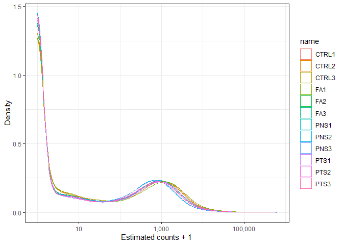

```r
exp_data %>%
  pivot_longer(!ENSG) %>%
  ggplot(aes(x=value + 1, color = name)) +
    geom_density() +
    scale_x_continuous(trans = 'log10', labels = scales::comma) +
  labs(x = "Estimated counts + 1", y = "Density")
```

Seems like most genes have too few reads so we remove genes without counts across all samples. Then we repeat the density plot.

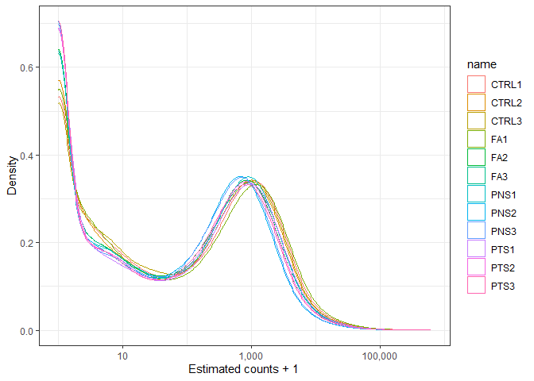

```r
exp_data <- exp_data[rowSums(exp_data[, .SD, .SDcols = !"ENSG"] == 0) < ncol(exp_data)-1]
exp_data %>%
  pivot_longer(!ENSG) %>%
  ggplot(aes(x=value + 1, color = name)) +
    geom_density() +
    scale_x_continuous(trans = 'log10', labels = scales::comma)+
  labs(x = "Estimated counts + 1", y = "Density")
```

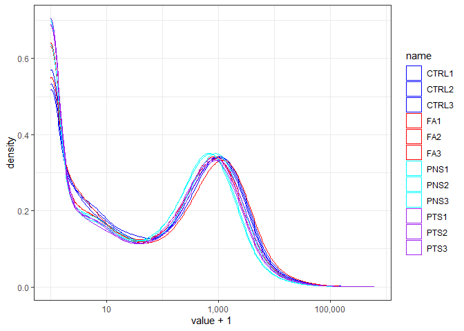

```r
temp <- exp_data %>%
  pivot_longer(!ENSG) %>%
  mutate(condition = gsub(pattern = "\\d+", replacement = "", x = name)) %>%
  mutate(condition = case_when(
    condition == "CTRL" ~ "blue",
    condition == "FA" ~ "red",
    condition == "PNS" ~ "cyan",
    condition == "PTS" ~ "purple"))


temp %>%
  ggplot(aes(x=value + 1, color= name))+
  geom_density() +
  scale_x_continuous(trans = 'log10', labels = scales::comma) +
  scale_color_manual(values = temp$condition,
                     breaks = temp$name)
```

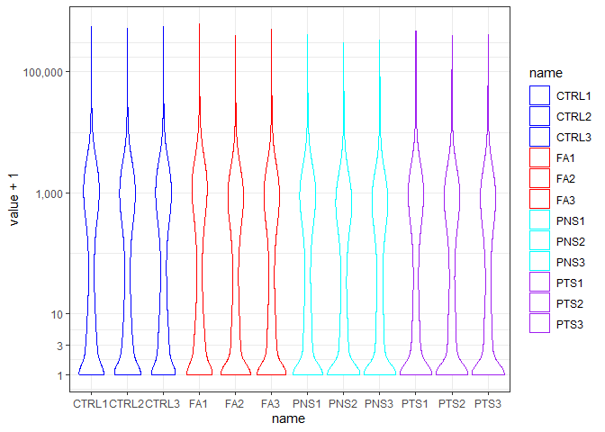

```r
temp %>%
  ggplot(aes(x = name, y = value + 1, color= name))+
  geom_violin() +
  scale_y_continuous(trans = 'log10', labels = scales::comma,
                     breaks = c(1, 3, 10, 1000, 100000)) +
  scale_color_manual(values = temp$condition,
                     breaks = temp$name)
```

We can observe that all samples have similar expression trends.

### 1.2.1 Filter lowly expressed genes

To increase data quality we removed lowly expressed genes in two steps:

```r
# Remove columns with gene information
exp_mat <- exp_data %>%
  column_to_rownames("ENSG")
# Remove rows with all entries equal zero
exp_mat <- exp_mat[!(rowSums(exp_mat <= 2) == ncol(exp_mat)),]
```

```r
# We use the average 1st quartile as threshold (2.55), round down to 2
# floor(mean(apply(exp_mat, MARGIN = 2, quantile, 0.25)))

# Select genes to keep
min_reads <- 4
min_samples <- 10
genes_to_keep <- apply(exp_mat >= min_reads,
                       MARGIN = 1, sum) > min_samples

# Final gene count matrix
exp_mat <- exp_mat[genes_to_keep,]
```

Now we repeat the previous visualizations to explore how the count distributions changed after filtering

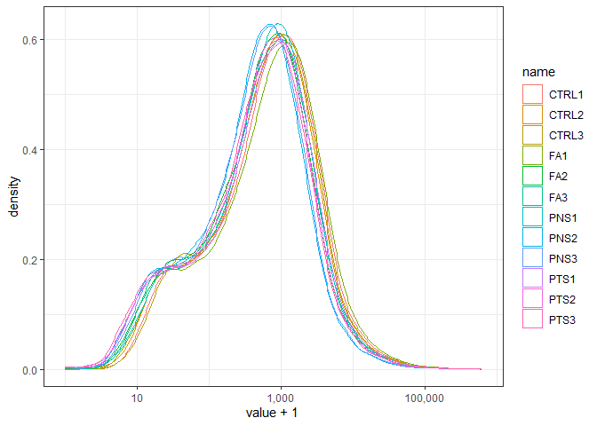

```r
exp_mat %>%
  rownames_to_column("ENSG") %>%
  pivot_longer(!ENSG) %>%
  ggplot(aes(x=value + 1, color = name)) +
    geom_density() +
    scale_x_continuous(trans = 'log10', labels = scales::comma)
```

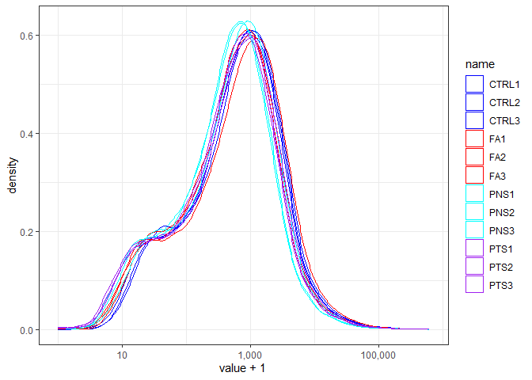

```r
temp <- exp_mat  %>%
  rownames_to_column("ENSG") %>%
  pivot_longer(!ENSG) %>%
  mutate(condition = gsub(pattern = "\\d+", replacement = "", x = name)) %>%
  mutate(condition = case_when(
    condition == "CTRL" ~ "blue",
    condition == "FA" ~ "red",
    condition == "PNS" ~ "cyan",
    condition == "PTS" ~ "purple"))

temp %>%
  ggplot(aes(x=value + 1, color= name))+
  geom_density() +
  scale_x_continuous(trans = 'log10', labels = scales::comma) +
  scale_color_manual(values = temp$condition,
                     breaks = temp$name)
```

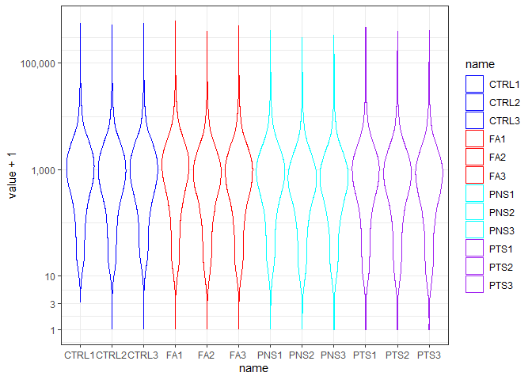

```r
temp %>%
  ggplot(aes(x = name, y = value + 1, color= name))+
  geom_violin() +
  scale_y_continuous(trans = 'log10', labels = scales::comma,
                     breaks = c(1, 3, 10, 1000, 100000)) +
  scale_color_manual(values = temp$condition,
                     breaks = temp$name)
```

This step made samples distributions to look mostly normal on the log10 + 1 scale.

## 1.3 CPM normalization

Before proceeding to further analysis we need to normalize the gene counts, we will use *counts per million* (CPM) to adjust for library size and transform it to log space for better visualization.

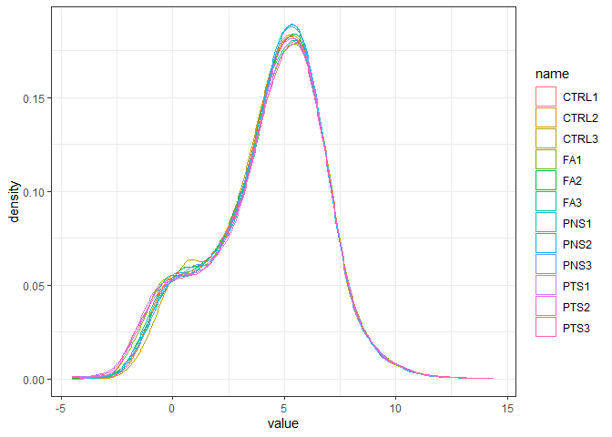

```r
# CPM normalization and transform to log2
expr_log2cpm <- cpm(exp_mat,
                    log = TRUE,
                    prior.count = 1) %>%
  data.frame()

expr_log2cpm %>%
  rownames_to_column(var = "ENSG") %>%
  pivot_longer(!ENSG) %>%
  dplyr::select(!ENSG) %>%
  ggplot(aes(x=value, color= name))+
  geom_density()
```

### 1.3.1 Violin plots

To directly compare sample gene expression distribution without overlap between density plots we generated the respective violin plots

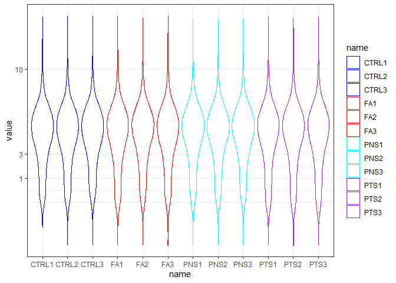

```r
temp <- expr_log2cpm %>%
  rownames_to_column("ENSG") %>%
  pivot_longer(!ENSG) %>%
  mutate(condition = gsub(pattern = "\\d+", replacement = "", x = name)) %>%
  mutate(condition = case_when(
    condition == "CTRL" ~ "blue",
    condition == "FA" ~ "red",
    condition == "PNS" ~ "cyan",
    condition == "PTS" ~ "purple"))


temp %>%
  ggplot(aes(x = name, y = value, color= name))+
  geom_violin() +
  scale_y_continuous(breaks = c(1, 3, 10, 1000, 100000)) +
  scale_color_manual(values = temp$condition,
                     breaks = temp$name)
```

### 1.3.2 Sample-sample correlation plot

Using normalized counts we generated a plot to observe if there is correlation within diet groups which would group the samples accordingly.

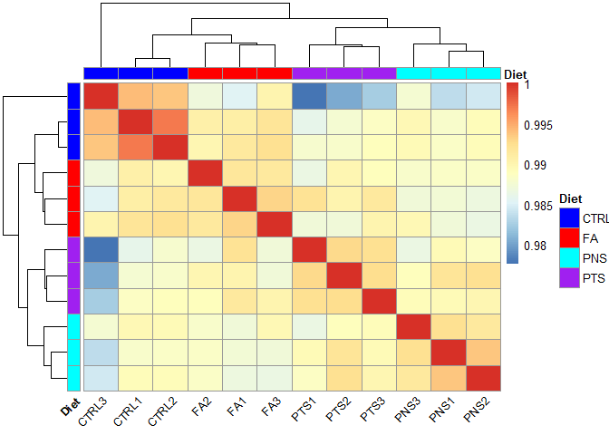

```r
# Annotation

# Standardize conditon names
condition <- names(expr_log2cpm) %>%
  str_extract(pattern = "^(CTRL|FA|PNS|PTS)")

annot <- data.frame(Diet = as.factor(condition),
                    row.names = names(expr_log2cpm))


annot_colors <- list(Diet = c("CTRL" = "blue",
                              "FA" = "red",
                              "PNS" = "cyan",
                               "PTS" = "purple"))

# Heatmap
expr_log2cpm %>%
  cor(method = "spearman") %>%
  pheatmap(annotation_col = annot,
           annotation_row = annot,
           show_rownames = FALSE,
           annotation_colors = annot_colors,
           angle_col = 45)
```

### 1.3.3 Principal Component Analysis (PCA)

Another way of determining relationship between the samples is through a PCA analysis, which reduces the dimentionality of our data to a set of independent variables (principal components) that represent the major proportion of variability in our data.

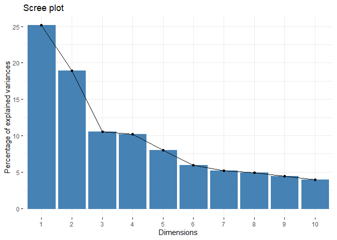

```r
PCs <- prcomp(t(cpm(exp_mat)), center = TRUE, scale = TRUE)
# Scree plot
fviz_eig(PCs)
```

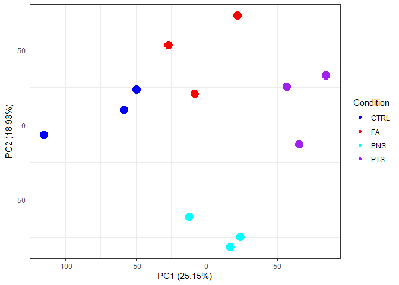

```r
# Scatter plot
eig_val <- get_eigenvalue(PCs)
PCs <- cbind(annot, PCs$x[,1:10])
PCs$sample_id <- rownames(PCs)

PCs <- PCs %>%
  mutate(color_class = case_when(
    condition == "CTRL" ~ "blue",
    condition == "FA" ~ "red",
    condition == "PNS" ~ "cyan",
    condition == "PTS" ~ "purple"))

PCs %>%
  ggplot(aes(x = PC1, y = PC2,
             color = condition)) +
  geom_point(aes(size = 8)) +
  scale_color_manual(values = PCs$color_class,
                     breaks = PCs$Diet) +
  labs(x= paste("PC1 (",round(eig_val$variance.percent[1], 2),"%)", sep = ""),
       y= paste("PC2 (",round(eig_val$variance.percent[2], 2),"%)", sep = ""),
       color = "Condition")+
  guides(size = "none") +
  theme_bw()
```

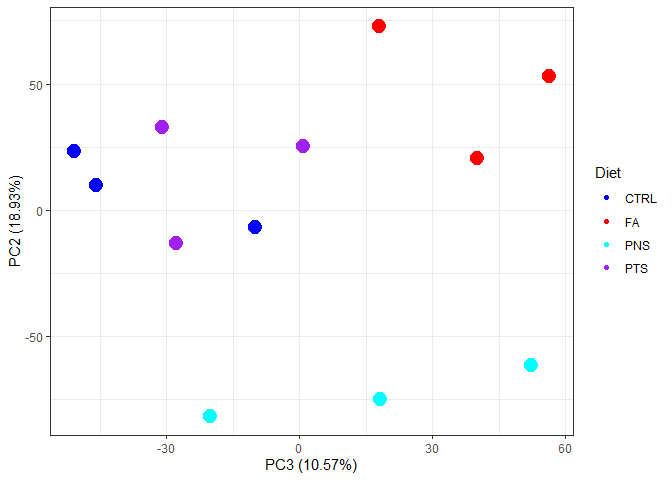

```r
PCs %>%
  ggplot(aes(x = PC3, y = PC2,
             color = Diet)) +
  geom_point(aes(size = 8)) +
  scale_color_manual(values = PCs$color_class,
                     breaks = PCs$Diet) +
  labs(x= paste("PC3 (",round(eig_val$variance.percent[3], 2),"%)", sep = ""),
       y= paste("PC2 (",round(eig_val$variance.percent[2], 2),"%)", sep = ""))+
  guides(size = "none") +
  theme_bw()
```

#### 1.3.3.1 Clustering and PCA on top variable genes

For scenarios where experimental variability is expected to be low, it is worth looking at genes with the highest overall variability. If we expect a few differentially expressed genes, the signal is likely to get lost among many genes with no expression changes.

```r
temp <- DESeq2::vst(as.matrix(ceiling(exp_mat)))
```

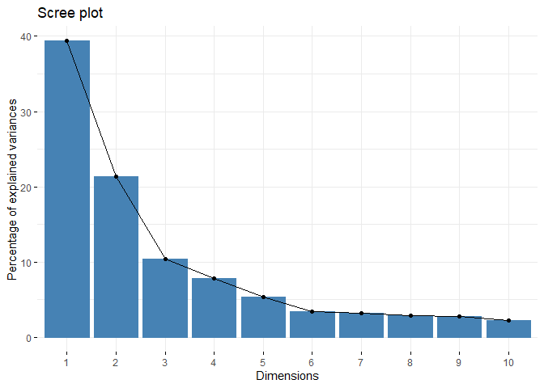

```r
#Top 10% variable
index <- which( rownames(temp) %in% names(sort(apply(X = temp,
                                                     MARGIN = 1,
                                                     var),
                                               decreasing = TRUE)[1:ceiling(nrow(temp) * 0.2)]))
temp <- temp[index,]

PCs <- prcomp(t(temp), center = TRUE, scale = TRUE)
# Scree plot
fviz_eig(PCs)
```

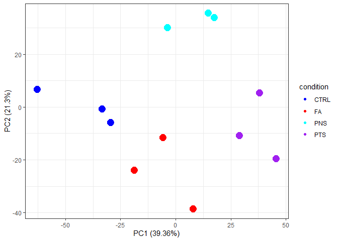

```r
# Scatter plot
eig_val <- get_eigenvalue(PCs)
PCs <- cbind(annot, PCs$x[,1:10])
PCs$sample_id <- rownames(PCs)

PCs <- PCs %>%
  mutate(color_class = case_when(
    condition == "CTRL" ~ "blue",
    condition == "FA" ~ "red",
    condition == "PNS" ~ "cyan",
    condition == "PTS" ~ "purple"))

PCs %>%
  ggplot(aes(x = PC1, y = PC2,
             color = condition)) +
  geom_point(aes(size = 8)) +
  scale_color_manual(values = PCs$color_class,
                     breaks = PCs$Diet) +
  labs(x= paste("PC1 (",round(eig_val$variance.percent[1], 2),"%)", sep = ""),
       y= paste("PC2 (",round(eig_val$variance.percent[2], 2),"%)", sep = ""))+
  guides(size = "none") +
  theme_bw()
```

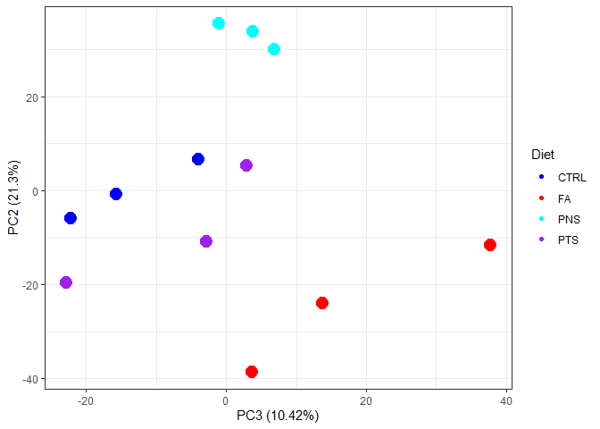

```r
PCs %>%
  ggplot(aes(x = PC3, y = PC2,
             color = Diet)) +
  geom_point(aes(size = 8)) +
  scale_color_manual(values = PCs$color_class,
                     breaks = PCs$Diet) +
  labs(x= paste("PC3 (",round(eig_val$variance.percent[3], 2),"%)", sep = ""),
       y= paste("PC2 (",round(eig_val$variance.percent[2], 2),"%)", sep = ""))+
  guides(size = "none") +
  theme_bw()
```

Considering only the top 20% variable genes, most of the expression differences between samples could be explained by the first two PCs.

# 2 DESeq2 analysis

After verifying the data was correctly processed, we performed a differential expression analysis using DESeq2.

The groups tested were:

```r
deseq2_res <- fread("~/GitHub/RNAseq_amelie/output/DEG_results.tsv")
unique(deseq2_res$Group)
```

```
## [1] "FA_vs_Ctrl"  "PNS_vs_CTRL" "PTS_vs_CTRL" "PNS_vs_FA"   "PTS_vs_FA"
```

```r
alpha <- 0.05
log2FC <- 0.58
```

## 2.1 Fatty Acid vs Control

This is the baseline expression differences.

```r
de_res <- deseq2_res[Group == "FA_vs_Ctrl"]
de_res[ , Group := NULL]
de_res[ , ensembl_gene_id := NULL]
de_res[ , entrezgene_id := NULL]
de_res <- unique(de_res)
setnames(de_res, "external_gene_name", "geneID")
de_res[padj <= alpha, ]
```

| geneID | baseMean | log2FoldChange | lfcSE | stat | pvalue | padj |
| --- | --- | --- | --- | --- | --- | --- |
| GCLC | 2859.21229 | 1.0554069 | 0.09757582 | 10.816275 | 2.882547e-27 | 5.657479e-24 |
| CYP26B1 | 89.23757 | -1.5811948 | 0.34881363 | -4.533065 | 5.813397e-06 | 3.680568e-04 |
| PDK4 | 5054.67923 | 2.2201564 | 0.11572319 | 19.185061 | 4.933648e-82 | 5.809864e-78 |
| SLC25A13 | 714.79534 | -0.5264015 | 0.17537302 | -3.001610 | 2.685556e-03 | 4.402131e-02 |
| DHX33 | 1348.30005 | -0.3103181 | 0.08631833 | -3.595043 | 3.243386e-04 | 8.986850e-03 |
| GDE1 | 2667.37542 | 0.2437267 | 0.08057586 | 3.024810 | 2.487891e-03 | 4.173419e-02 |
| RPUSD1 | 634.15299 | -0.4587406 | 0.11927890 | -3.845949 | 1.200867e-04 | 4.208754e-03 |
| CYB561 | 1440.01300 | 0.4137241 | 0.10492022 | 3.943226 | 8.039298e-05 | 3.134794e-03 |
| MGST1 | 7700.12973 | 0.2961123 | 0.08012293 | 3.695724 | 2.192607e-04 | 6.603616e-03 |
| RHOBTB2 | 2059.52112 | -0.6131662 | 0.10776028 | -5.690095 | 1.269689e-08 | 1.941799e-06 |

[output cut: 737 more lines]

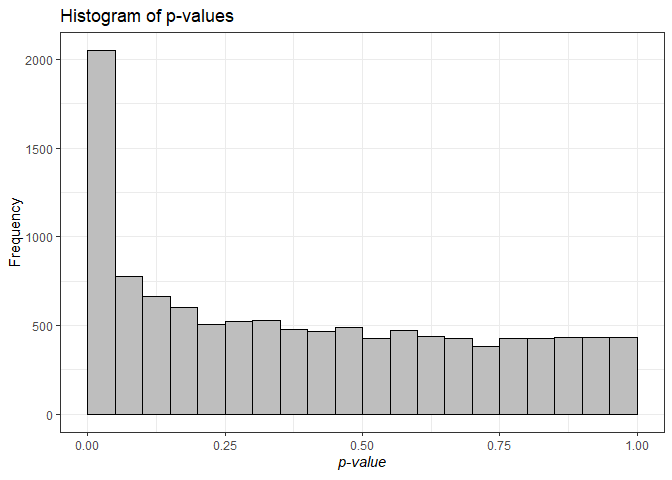

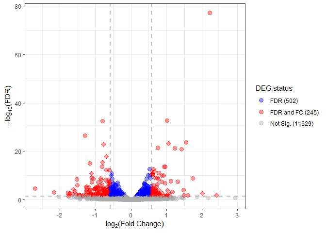

```r
temp <- visualize_degs(de_res, alpha, log2FC)
temp
```

## 2.2 PNS vs Fatty Acid

```r
de_res <- deseq2_res[Group == "PNS_vs_FA"]
de_res[ , Group := NULL]
de_res[ , ensembl_gene_id := NULL]
de_res[ , entrezgene_id := NULL]
de_res <- unique(de_res)
setnames(de_res, "external_gene_name", "geneID")
de_res[padj <= alpha, ]
```

| geneID | baseMean | log2FoldChange | lfcSE | stat | pvalue | padj |
| --- | --- | --- | --- | --- | --- | --- |
| GCLC | 2859.21229 | -1.0338266 | 0.09799755 | -10.549515 | 5.105990e-26 | 4.000224e-23 |
| LAP3 | 1153.17577 | -0.2927190 | 0.09641021 | -3.036183 | 2.395939e-03 | 3.061478e-02 |
| KDM1A | 2866.83483 | -0.2612459 | 0.06572662 | -3.974735 | 7.045765e-05 | 2.241590e-03 |
| PDK4 | 5054.67923 | -0.4713901 | 0.11490857 | -4.102306 | 4.090527e-05 | 1.445082e-03 |
| KMT2E | 2478.93700 | -0.4247967 | 0.09014386 | -4.712431 | 2.447795e-06 | 1.461101e-04 |
| ZNF195 | 456.72125 | 0.5638871 | 0.16592782 | 3.398388 | 6.778418e-04 | 1.251362e-02 |
| PDK2 | 218.38475 | -0.9776313 | 0.16641794 | -5.874555 | 4.239814e-09 | 5.776746e-07 |
| ITGA3 | 8539.80865 | 0.3946910 | 0.08316929 | 4.745634 | 2.078542e-06 | 1.296245e-04 |
| CRLF1 | 81.25711 | 1.1558296 | 0.40545111 | 2.850725 | 4.361966e-03 | 4.729866e-02 |
| MAP3K14 | 412.41462 | -0.5059018 | 0.13258513 | -3.815676 | 1.358108e-04 | 3.717005e-03 |

[output cut: 1156 more lines]

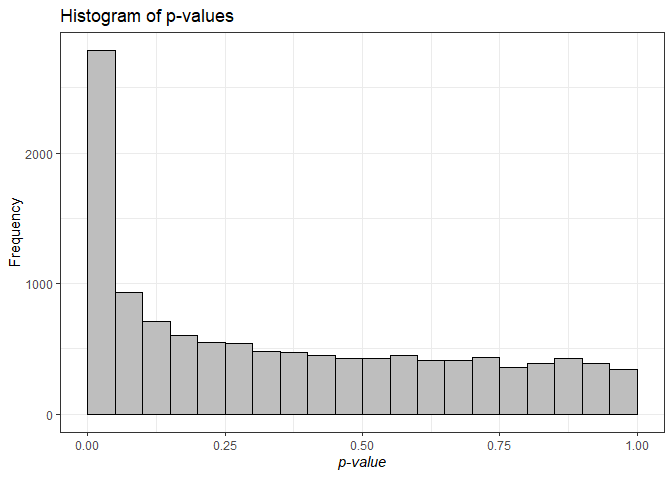

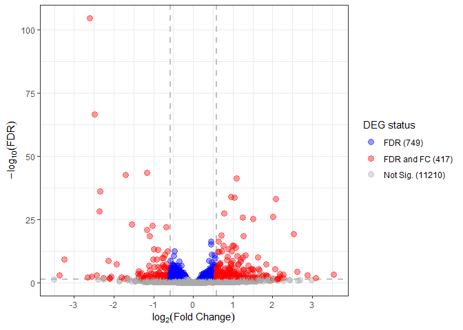

```r
temp <- visualize_degs(de_res, alpha, log2FC)
temp
```

## 2.3 PTS vs Fatty Acid

```r
de_res <- deseq2_res[Group == "PTS_vs_FA"]
de_res[ , Group := NULL]
de_res[ , ensembl_gene_id := NULL]
de_res[ , entrezgene_id := NULL]
de_res <- unique(de_res)
setnames(de_res, "external_gene_name", "geneID")
de_res[padj <= alpha, ]
```

| geneID | baseMean | log2FoldChange | lfcSE | stat | pvalue | padj |
| --- | --- | --- | --- | --- | --- | --- |
| GCLC | 2859.21229 | -0.6195975 | 0.09751896 | -6.353610 | 2.103194e-10 | 6.324829e-08 |
| RAD52 | 317.69518 | -0.6527258 | 0.15959306 | -4.089939 | 4.314872e-05 | 2.348579e-03 |
| MAD1L1 | 582.79832 | 0.5045850 | 0.16114683 | 3.131213 | 1.740861e-03 | 3.277123e-02 |
| PDK4 | 5054.67923 | -1.0030626 | 0.11506183 | -8.717596 | 2.841717e-18 | 2.629462e-15 |
| PDK2 | 218.38475 | -0.9553343 | 0.16546851 | -5.773512 | 7.763627e-09 | 1.697976e-06 |
| TMEM132A | 985.31360 | -0.6907257 | 0.17003805 | -4.062183 | 4.861598e-05 | 2.587618e-03 |
| TNFRSF12A | 2338.75751 | 0.3786104 | 0.11023100 | 3.434699 | 5.932116e-04 | 1.554355e-02 |
| DBF4 | 949.17555 | 0.6887578 | 0.21809387 | 3.158080 | 1.588121e-03 | 3.081211e-02 |
| IFRD1 | 2487.74523 | 0.3181883 | 0.08677494 | 3.666822 | 2.455833e-04 | 8.368616e-03 |
| AASS | 411.68865 | -0.4920701 | 0.13989183 | -3.517504 | 4.356253e-04 | 1.260515e-02 |

[output cut: 744 more lines]

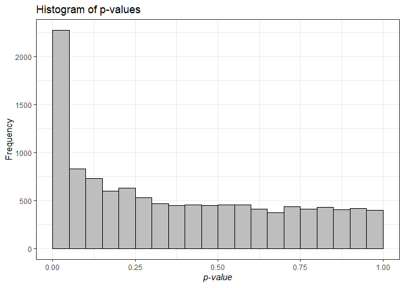

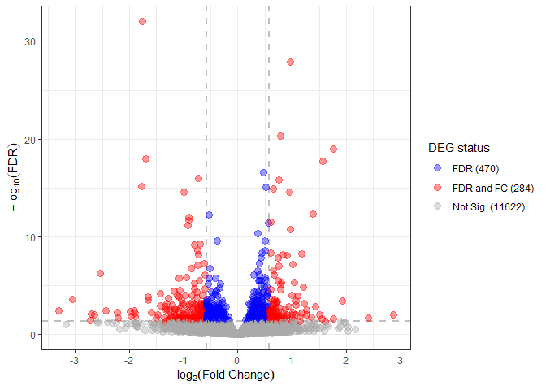

```r
temp <- visualize_degs(de_res, alpha, log2FC)
temp
```